# ETM 58D Homework 1

Cagatay Yurdasal & Gulnur Acar

24 Mart 2019

# Task 1

In this part, we were supposed to evaluate how successfull bookmakers estimate the probabilities of the result of the game depending on the total number of goals. To examine success rate, match results and prior bets for these matches of bookmakers are used. We followed the steps below:

- Cleaned data inconsistencies
  - Strings pointing the same teams are unified
  - The matches which have no results in data are removed
  - The matches which are postponed are removed
- Epoch data converted into readable timestamps
- Scores are converted from strings to divided integers
- Results in terms of total goals are calculated
- 5 bookmakers are chosen; ‘BetVictor’, ‘10Bet’, ‘bwin’, ‘bet365’ and ‘Pinnacle’
- Initial and final odds are selected to examine the change in success
- Probabilities are calculated from the given bets in a normalized way

## Part A

To ease the analysis we discretized probabilities into 0.05 probability chunks & mapped the match statistics. In our visualization, we found that the bins which have a few results deviated from the success line and became outliers. In general bookmakers’ estimations were close to the actual results.

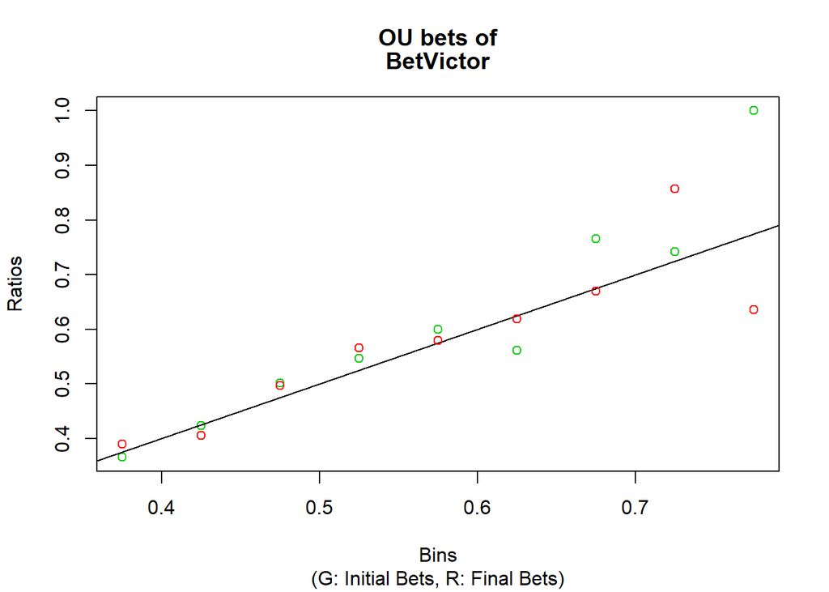

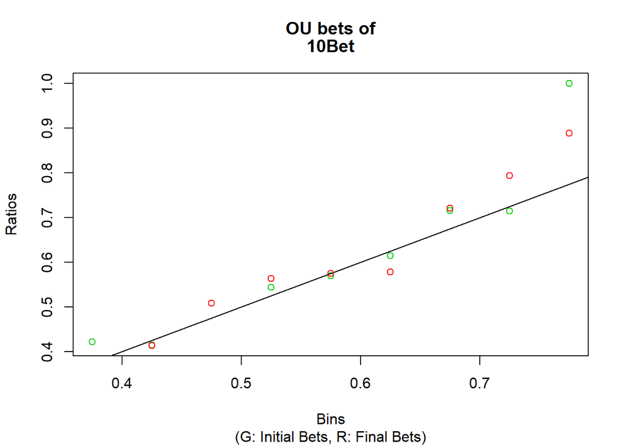

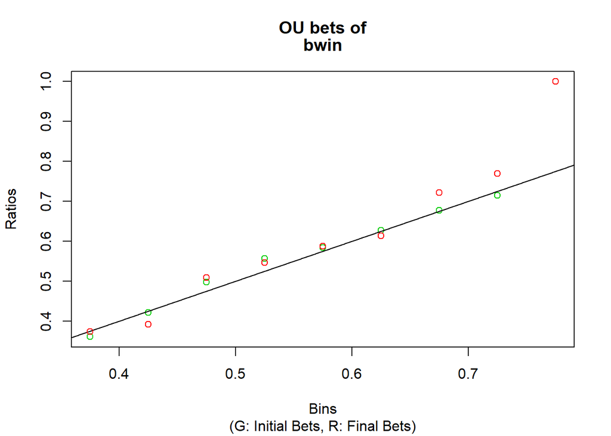

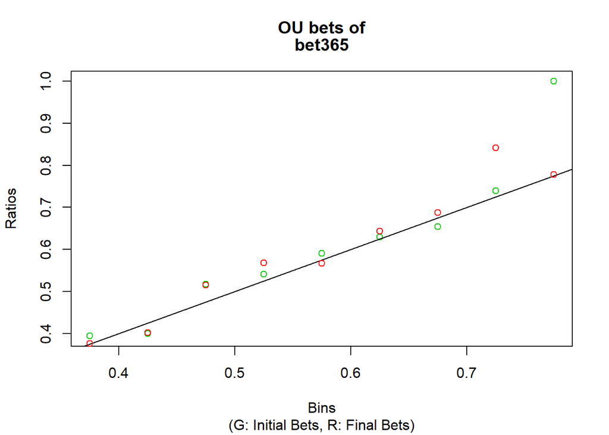

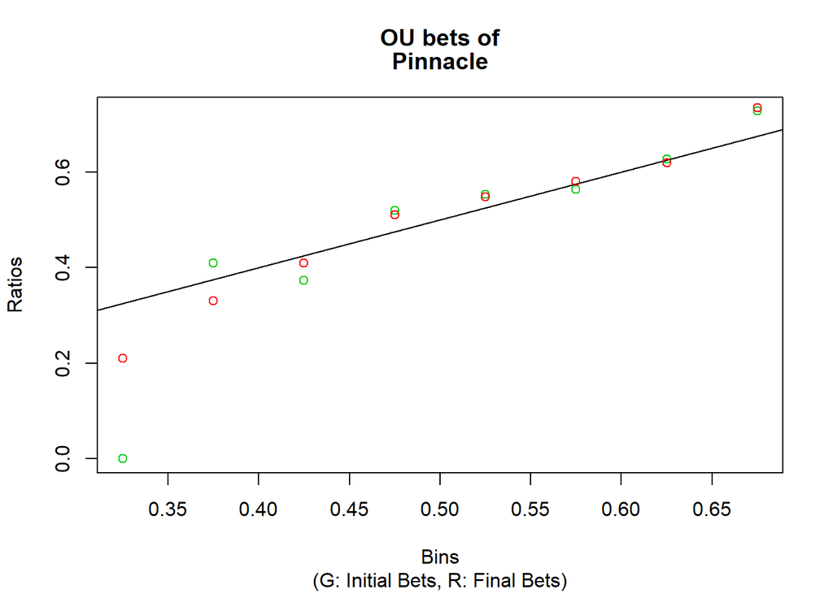

## Part B

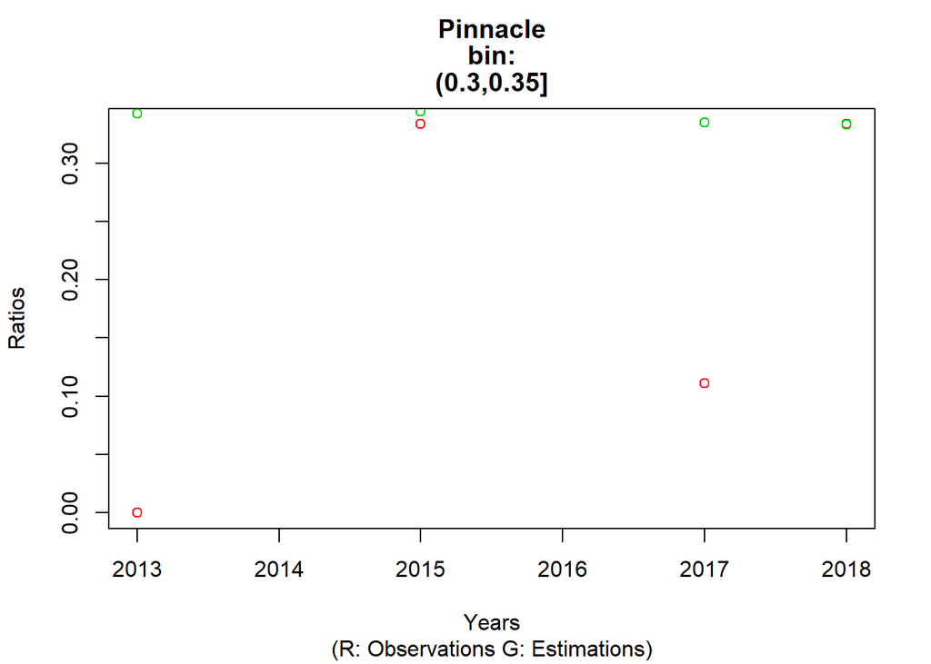

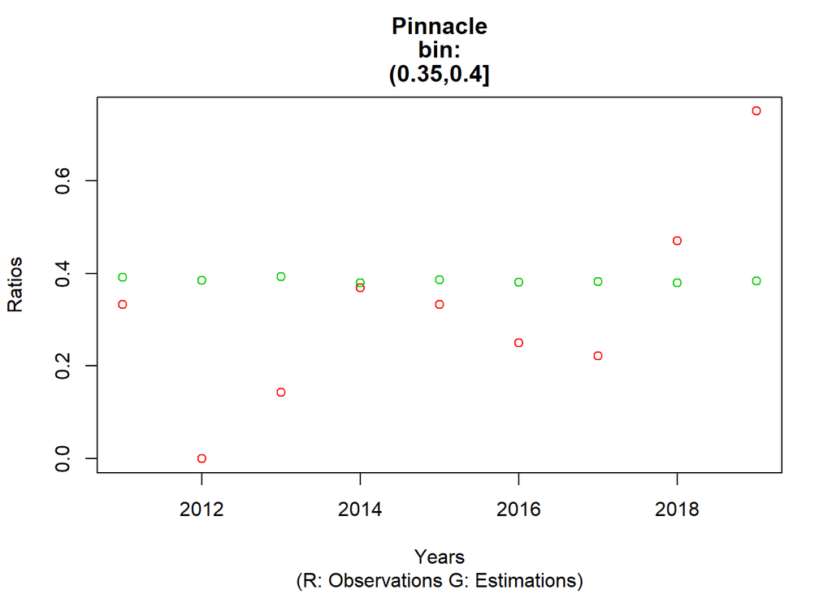

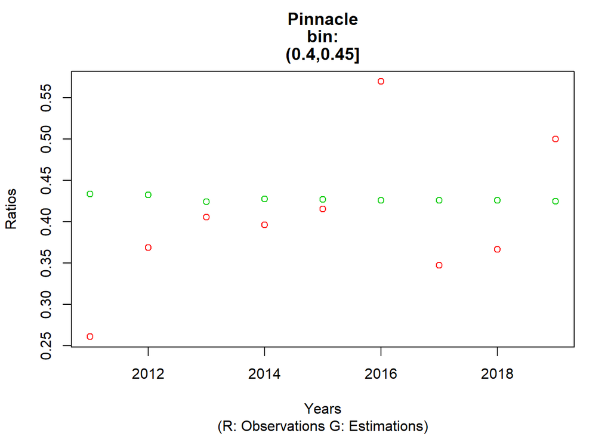

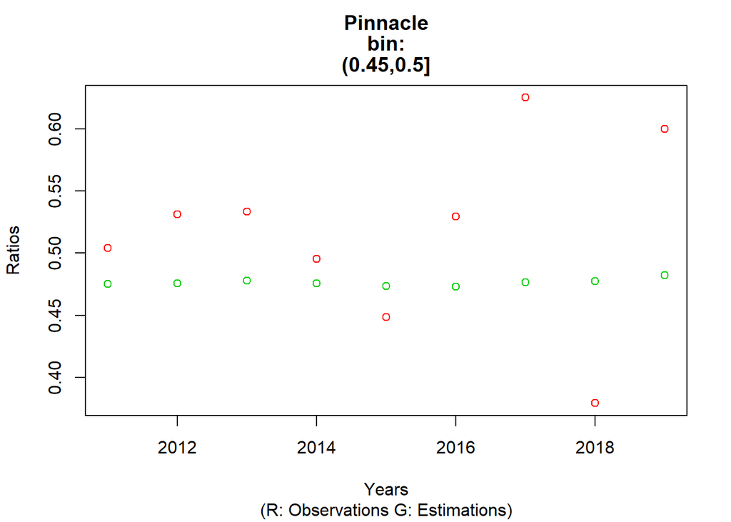

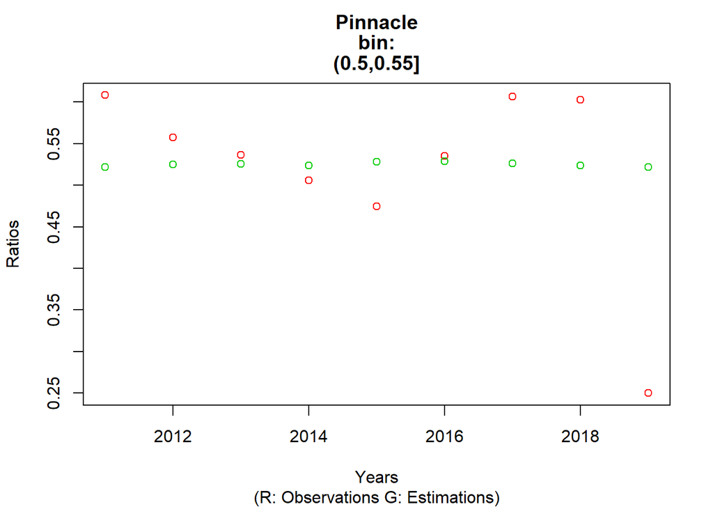

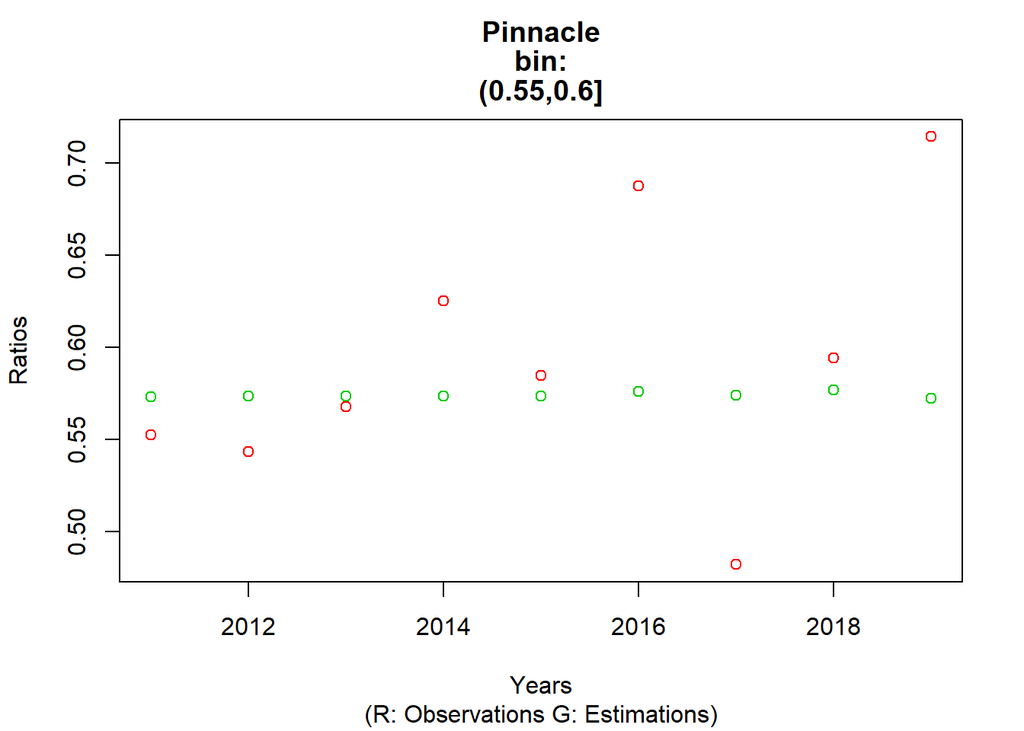

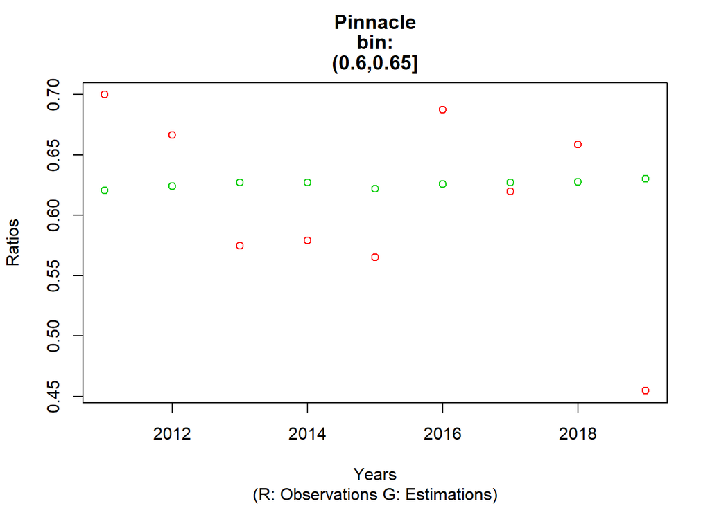

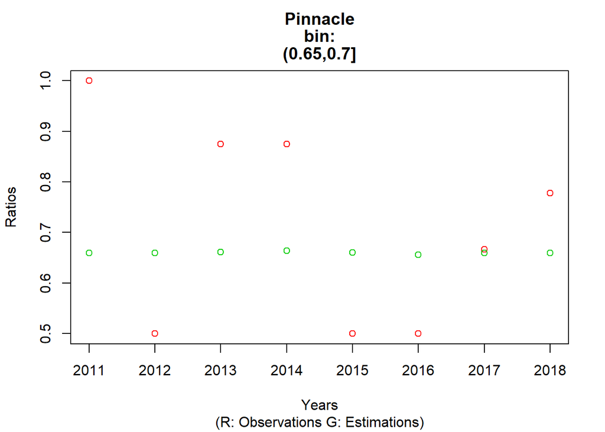

# Task 2

In this task, we tried to track the changes in directions using the actual scores. * For all bet types -Home, Away and Draw- if a given probability by the bookmaker (Selected Pinnacle) is bigger and the result is complied with that bet then the bet change gets +1 point. * Continuing with this logic, if the bet change is in the wrong direction then the acquired point is -1. * Nonchanging bets assigned as 0 points.

At the end annual scores for changes in all bet types are visualized. We observed that there is no significant change until 2016. After that, the changes increased significantly. It may be a result of change of brand and company structure. In 2016, “Pinnacle Sports” rebranded to “Pinnacle”. This change might differ company strategy/resources to modelling/modelling techniques. An alternative approach may be changes of the bet structures and information flow for modelling in general. In order to claim such alternatives the other bookmakers should be examined as a future work.

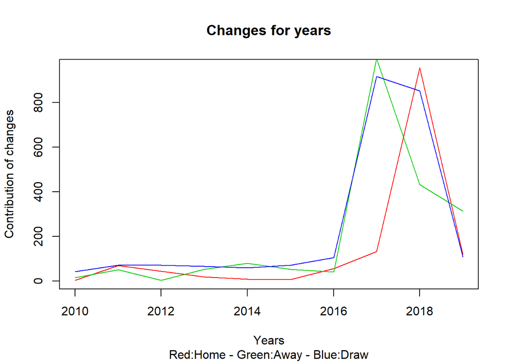

# Appendix

## r code

```
# Init files----
#
require(data.table)
require(lubridate)
# read matches info
matches=readRDS('df9b1196-e3cf-4cc7-9159-f236fe738215_matches.rds')
# read odds data
odds=readRDS('df9b1196-e3cf-4cc7-9159-f236fe738215_odd_details.rds')

# Data corrections----
# delete these column
matches$type=NULL
matches$leagueId=NULL

# fix home teams
matches[home=='manchester-city',home:='manchester city']
matches[home=='crystal-palace',home:='crystal palace']
matches[home=='newcastle utd',home:='newcastle']
matches[home=='stoke',home:='stoke city']
matches[home=='west-ham',home:='west ham']
matches[home %in% c('manchester-united','manchester-utd'), home:='manchester united']

# fix away teams
matches[away=='manchester-city',away:='manchester city']
matches[away=='crystal-palace',away:='crystal palace']
matches[away=='newcastle utd',away:='newcastle']
matches[away=='stoke',away:='stoke city']
matches[away=='west-ham',away:='west ham']
matches[away %in% c('manchester-united','manchester-utd'), away:='manchester united']

# remove unknown scores & postponed matches
matches <- matches[!is.na(score)]
matches <- matches[!score=='POSTP.']

# date operations
matches[,timestamp:=as_datetime(date,tz='Turkey')]
matches[,date:=NULL]
matches[,year:=year(timestamp)]

# Data manipulation----
```

[output cut: 230 more lines]

```
     summary$home,
     col=2,
     type = 'l',
     main='Changes for years',
     sub='Red:Home - Green:Away - Blue:Draw',
     xlab='Years',
     ylab='Contribution of changes')
lines(summary$year,
      summary$away,
      col=3,
      type = 'l')
lines(summary$year,
      summary$draw,
      col=4,
      type = 'l')
```